# Electromagnetism

- Show All Code
- Hide All Code
- View Source

## Electrostatics

### Coulomb’s Law

In 1785, Charles-Augustin de Coulomb formulated the law that describes the force between two electrically charged particles. This foundational principle quantifies the interaction between charged objects and laid the groundwork for the study of electrostatics.

**Coulomb’s Law**:

Suppose we have a two point charges $q$ and $Q$ at positions $\mathbf{r}=(x,y,z)$ and $\mathbf{r}'=(x',y',z')$ respectively. The force $\mathbf{F}$ acting on $Q$ by $q$ is given by

$$\mathbf{F} = \frac{1}{4\pi\epsilon_0}\frac{qQ}{|\mathbf{r}-\mathbf{r}'|^3}(\mathbf{r}-\mathbf{r}')$$

where:

- $\mathbf{F}$ is the force vector acting on charge $Q$,
- $\epsilon_0$ is the permittivity of free space.
- $q$ is the charge of the first particle,
- $Q$ is the charge of the second particle,
- $\mathbf{r}$ is the position vector of charge $Q$,
- $\mathbf{r}'$ is the position vector of charge $q$,
- $|\mathbf{r}-\mathbf{r}'|$ is the distance between the two charges,

where $\epsilon_0$ is the vacuum permittivity.

It is ease to observe that the force is attractive if the charges are of opposite sign and repulsive if they are of the same sign. Secondly, the force has same structure as the gravitational force, which is given by

$$\mathbf{F} = -G\frac{Mm}{|\mathbf{r}-\mathbf{r}'|^3}(\mathbf{r}-\mathbf{r}')$$

where:

- $\mathbf{F}$ is the gravitational force vector acting on mass $m$,
- $G$ is the gravitational constant,
- $M$ is the mass of the first particle,
- $m$ is the mass of the second particle,
- $\mathbf{r}$ is the position vector of mass $m$,
- $\mathbf{r}'$ is the position vector of mass $M$,
- $|\mathbf{r}-\mathbf{r}'|$ is the distance between the two masses.

[interactive chart not shown]

html_anim/electromagnetism/coloumb_law.html

### Electric Field

The electric field $\mathbf{E}$ is a vector field that describes the force per unit charge experienced by a positive test charge placed in the vicinity of other charges. The electric field due to a point charge $q$ at a position $\mathbf{r}'$ is given by:

$$\mathbf{E}(\mathbf{r}) = \frac{1}{4\pi\epsilon_0}\frac{Q}{|\mathbf{r}-\mathbf{r}'|^3}(\mathbf{r}-\mathbf{r}')$$

#### Superposition Principle

The electric field due to multiple point charges can be calculated using the superposition principle. The total electric field $\mathbf{E}_{\text{total}}$ at a point $\mathbf{r}$ due to a set of point charges $q_1, q_2, \ldots, q_n$ located at positions $\mathbf{r}_1, \mathbf{r}_2, \ldots, \mathbf{r}_n$ is given by:

$$\mathbf{E}_{\text{total}}(\mathbf{r}) = \sum_{i=1}^{n} \mathbf{E}_i(\mathbf{r}) = \sum_{i=1}^{n} \frac{1}{4\pi\epsilon_0}\frac{Q_i}{|\mathbf{r}-\mathbf{r}_i|^3}(\mathbf{r}-\mathbf{r}_i)$$

where $\mathbf{E}_i(\mathbf{r})$ is the electric field due to the $i$-th charge at position $\mathbf{r}_i$.

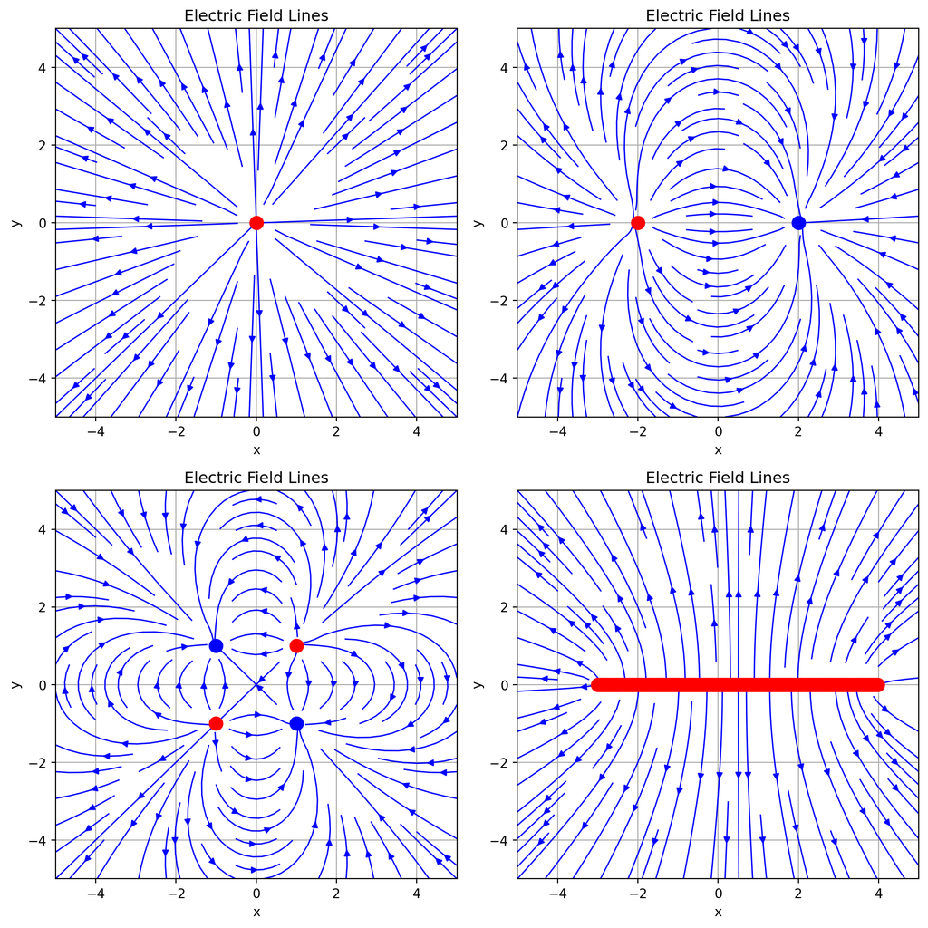

```python
import numpy as np
import matplotlib.pyplot as plt

def draw_electric_field(charges, ax):
    # Create a grid of points in 2D space
    x = np.linspace(-5, 5, 30)
    y = np.linspace(-5, 5, 30)
    X, Y = np.meshgrid(x, y)

    # Initialize electric field components
    Ex = np.zeros(X.shape)
    Ey = np.zeros(Y.shape)

    # Coulomb's constant (simplified for visualization)
    k = 1

    # Calculate the field for each charge
    for charge, pos_x, pos_y in charges:
        # Vector from the charge to the point
        r_x = X - pos_x
        r_y = Y - pos_y
        r = np.sqrt(r_x**2 + r_y**2)

        # Prevent division by zero
        r = np.maximum(r, 0.1)

        # Electric field E = k * q / r^2, split into components
        E = k * charge / r**2
        Ex += E * r_x / r
        Ey += E * r_y / r

    # Draw field lines using streamplot on the given axis
    ax.streamplot(X, Y, Ex, Ey, color='blue', linewidth=1)

    # Plot the charges
    for charge, pos_x, pos_y in charges:
        if charge > 0:
            ax.plot(pos_x, pos_y, 'ro', markersize=10)  # Red for positive
        else:
            ax.plot(pos_x, pos_y, 'bo', markersize=10)  # Blue for negative

    ax.grid(True)
    ax.set_title("Electric Field Lines")
    ax.set_xlabel("x")
    ax.set_ylabel("y")

def draw_multiple_fields(configurations, layout):
    # Create a figure with subplots based on the layout
    fig, axes = plt.subplots(layout[0], layout[1], figsize=(layout[1] * 5, layout[0] * 5))

    # Flatten axes array if it's 2D for easier iteration
    axes = axes.flatten() if layout[0] > 1 or layout[1] > 1 else [axes]

    # Draw each configuration on its corresponding subplot
    for i, charges in enumerate(configurations):
        if i < len(axes):  # Ensure we don’t exceed the number of subplots
            draw_electric_field(charges, axes[i])

    plt.tight_layout()
    plt.show()

# Example usage: list of configurations and layout
configurations = [
    [(1, 0, 0)],
    [(1, -2, 0), (-1, 2, 0)],
    [(1, 1, 1), (-1,-1,1),(1,-1,-1),(-1,1,-1)],
    # [(1, 1, 1), (1,-1,1),(1,-1,-1),(1,1,-1)],
    [(1,i,0) for i in np.arange(-3, 4,0.02)],
]
layout = (2, 2)  # 1 row, 3 columns
draw_multiple_fields(configurations, layout)
```

If charge $Q$ is placed at position $\mathbf{r}$, the force acting on it due to the electric field is given by:

$$\mathbf{F} = Q \cdot \mathbf{E}_{\text{total}}(\mathbf{r})$$

## Continuous Charge Distribution

In many practical situations, charges are distributed over a volume, surface, or line rather than being concentrated at discrete points. In such cases, we can define charge density functions to describe the distribution of charge.

https://en.wikipedia.org/wiki/Electric_field

[interactive chart not shown]

html_anim/electromagnetism/integration_electric_field.html

### 1-D Charge Distribution

For a line of charge with linear charge density $\lambda(x,y,z)$, the total charge $dq$ in an infinitesimal length $dl$ is given by:

$$dq = \lambda(x,y,z) \, dl$$

where $dl$ is the infinitesimal length element along the line of charge. The electric field due to this line charge at a point $\mathbf{r}$ is given by:

$$\mathbf{E}(\mathbf{r}) = \int \frac{1}{4\pi\epsilon_0}\frac{\lambda(x,y,z)}{|\mathbf{r}-\mathbf{r}'|^3}(\mathbf{r}-\mathbf{r}') \, dl$$

where the integral is taken over the entire length of the line charge.

### 2-D Charge Distribution

For a surface of charge with surface charge density $\sigma(x,y,z)$, the total charge $dq$ in an infinitesimal area $dA$ is given by:

$$dq = \sigma(x,y,z) \, dA$$

where $dA$ is the infinitesimal area element on the surface of charge. The electric field due to this surface charge at a point $\mathbf{r}$ is given by:

$$\mathbf{E}(\mathbf{r}) = \int \frac{1}{4\pi\epsilon_0}\frac{\sigma(x,y,z)}{|\mathbf{r}-\mathbf{r}'|^3}(\mathbf{r}-\mathbf{r}') \, dA$$

where the integral is taken over the entire surface of charge.

### 3-D Charge Distribution

For a volume of charge with volume charge density $\rho(x,y,z)$, the total charge $dq$ in an infinitesimal volume $dV$ is given by:

$$dq = \rho(x,y,z) \, dV$$

where $dV$ is the infinitesimal volume element. The electric field due to this volume charge at a point $\mathbf{r}$ is given by:

$$\mathbf{E}(\mathbf{r}) = \int \frac{1}{4\pi\epsilon_0}\frac{\rho(x,y,z)}{|\mathbf{r}-\mathbf{r}'|^3}(\mathbf{r}-\mathbf{r}') \, dV$$

where the integral is taken over the entire volume of charge.

#### Example 1: Electric Field of an Infinitely Long Charged Line

Consider an infinitely long, uniformly charged line with linear charge density $\lambda$, aligned along the $z$-axis. Due to the cylindrical symmetry, the electric field $\mathbf{E}$ is radial, perpendicular to the line. We calculate the field at $\mathbf{r} = (x, 0, 0)$, a distance $x$ from the $z$-axis.

For a linear charge distribution, the electric field is:

$$\mathbf{E}(\mathbf{r}) = \int \frac{1}{4\pi\epsilon_0} \frac{\lambda(0,0,z)}{|\mathbf{r} - \mathbf{r}'|^3} (\mathbf{r} - \mathbf{r}') \, dl,$$

where

- $\mathbf{r}' = (0, 0, z')$ lies on the line
- $dl = dz'$, and $z'$ extends from $-\infty$ to $\infty$
- $\mathbf{r} - \mathbf{r}' = (x, 0, -z')$
- $|\mathbf{r} - \mathbf{r}'| = \sqrt{x^2 + z'^2}$.

The field components are:

$$\begin{align*}
E_x &= \frac{\lambda}{4\pi\epsilon_0} \int_{-\infty}^{\infty} \frac{x \, dz'}{(x^2 + z'^2)^{3/2}}, \\
E_y &= 0, \\
E_z &= \frac{\lambda}{4\pi\epsilon_0} \int_{-\infty}^{\infty} \frac{-z' \, dz'}{(x^2 + z'^2)^{3/2}}.
\end{align*}$$

The $z$-component **vanishes** due to symmetry, as the integrand is odd over symmetric limits. For the $x$-component:

$$E_x = \frac{\lambda x}{4\pi\epsilon_0} 2 \int_0^{\infty} \frac{dz'}{(x^2 + z'^2)^{3/2}}.$$

Using the substitution $z' = x \tan\theta$, $dz' = x \sec^2\theta \, d\theta$, the integral becomes:

$$\int_0^{\infty} \frac{dz'}{(x^2 + z'^2)^{3/2}} = \frac{1}{x^2} \int_0^{\pi/2} \cos\theta \, d\theta = \frac{1}{x^2} [\sin\theta]_0^{\pi/2} = \frac{1}{x^2}.$$

Thus:

$$E_x = \frac{\lambda x}{4\pi\epsilon_0} \cdot 2 \cdot \frac{1}{x^2} = \frac{\lambda}{2\pi\epsilon_0 x}.$$

The electric field is:

$$\mathbf{E} = \frac{\lambda}{2\pi\epsilon_0 x} \hat{x},$$

or, in general, at a radial distance $r = |x|$:

$$E = \frac{\lambda}{2\pi\epsilon_0 r},$$

directed radially outward, consistent with the symmetry.

### Example 2: Electric Field of an Infinite Charged Plane

Consider an infinite, uniformly charged plane with surface charge density $\sigma$, lying in the $xy$-plane at $z = 0$. Due to the planar symmetry, the electric field $\mathbf{E}$ is perpendicular to the plane, directed along the $z$-axis, and depends only on the distance from the plane. We calculate the field at a point $\mathbf{r} = (0, 0, z)$, a distance $z$ above the plane.

For a surface charge distribution, the electric field is:

$$\mathbf{E}(\mathbf{r}) = \int \frac{1}{4\pi\epsilon_0} \frac{\sigma}{|\mathbf{r} - \mathbf{r}'|^3} (\mathbf{r} - \mathbf{r}') \, dA,$$

where $\mathbf{r}' = (x', y', 0)$ is a point on the plane, and $dA = dx' \, dy'$ is the infinitesimal area element, integrated over the entire $xy$-plane. The vector $\mathbf{r} - \mathbf{r}' = (0, 0, z) - (x', y', 0) = (-x', -y', z)$, with magnitude $|\mathbf{r} - \mathbf{r}'| = \sqrt{x'^2 + y'^2 + z^2}$.

The $z$-component of the field is:

$$E_z = \frac{\sigma}{4\pi\epsilon_0} \int_{-\infty}^{\infty} \int_{-\infty}^{\infty} \frac{z \, dx' \, dy'}{(x'^2 + y'^2 + z^2)^{3/2}}.$$

Switching to polar coordinates, where $x' = r' \cos\theta$, $y' = r' \sin\theta$, and $dA = r' \, dr' \, d\theta$, with $r'$ from 0 to $\infty$ and $\theta$ from 0 to $2\pi$, the integral becomes:

$$E_z = \frac{\sigma z}{4\pi\epsilon_0} \int_0^{2\pi} d\theta \int_0^{\infty} \frac{r' \, dr'}{(r'^2 + z^2)^{3/2}}.$$

The angular part gives $2\pi$. For the radial integral, let $u = r'^2 + z^2$, so $du = 2 r' \, dr'$, and:

$$\int_0^{\infty} \frac{r' \, dr'}{(r'^2 + z^2)^{3/2}} = \int_{z^2}^{\infty} \frac{du}{2 u^{3/2}} = \left[ -\frac{1}{u^{1/2}} \right]_{z^2}^{\infty} = 0 - \left( -\frac{1}{|z|} \right) = \frac{1}{|z|}.$$

Thus:

$$E_z = \frac{\sigma z}{4\pi\epsilon_0} \cdot 2\pi \cdot \frac{1}{|z|} = \frac{\sigma}{2\epsilon_0} \frac{z}{|z|}.$$

The field is:

$$\mathbf{E} = \frac{\sigma}{2\epsilon_0} \hat{z} \quad (z > 0), \quad \mathbf{E} = -\frac{\sigma}{2\epsilon_0} \hat{z} \quad (z < 0),$$

with magnitude:

$$E = \frac{\sigma}{2\epsilon_0},$$

independent of distance, directed away from the plane on both sides.

### Example 3: Electric Field of a Uniformly Charged Sphere

Consider a solid sphere of radius $R$ with a uniform volume charge density $\rho$, centered at the origin. The spherical symmetry implies that the electric field $\mathbf{E}$ is radial, directed along $\hat{r}$, and its magnitude depends solely on the radial distance $r = |\mathbf{r}|$ from the center. We determine the field at a point $\mathbf{r} = (r, 0, 0)$ for two cases: $r > R$ (outside the sphere) and $r < R$ (inside the sphere), using the volume charge distribution formula:

$$\mathbf{E}(\mathbf{r}) = \int \frac{1}{4\pi\epsilon_0} \frac{\rho}{|\mathbf{r} - \mathbf{r}'|^3} (\mathbf{r} - \mathbf{r}') \, dV,$$

where $\mathbf{r}'$ is a position within the sphere, and $dV$ is the infinitesimal volume element, integrated over the sphere’s volume.

#### Outside the Sphere ($r > R$)

For a point outside the sphere ($r > R$), the entire charge of the sphere contributes to the field. The total charge $Q$ is the volume integral of the charge density:

$$Q = \rho \cdot \frac{4}{3}\pi R^3.$$

Spherical symmetry suggests the field behaves as if all charge were concentrated at the origin, like a point charge. To confirm, express the position of a charge element in spherical coordinates: $\mathbf{r}' = (r', \theta', \phi')$, with $r'$ from 0 to $R$, $\theta'$ from 0 to $\pi$, and $\phi'$ from 0 to $2\pi$. The volume element is $dV = r'^2 \sin\theta' \, dr' \, d\theta' \, d\phi'$. The distance $|\mathbf{r} - \mathbf{r}'| = \sqrt{r^2 + r'^2 - 2 r r' \cos\theta'}$, and the radial component of $\mathbf{r} - \mathbf{r}'$ dominates due to symmetry.

The electric field’s radial component is:

$$E_r = \frac{\rho}{4\pi\epsilon_0} \int_0^R \int_0^\pi \int_0^{2\pi} \frac{r - r' \cos\theta'}{(r^2 + r'^2 - 2 r r' \cos\theta')^{3/2}} r'^2 \sin\theta' \, d\phi' \, d\theta' \, dr'.$$

The $\phi'$-integral yields $2\pi$, as the field is azimuthally symmetric. The $\theta'$-integral simplifies with $u = \cos\theta'$, and for $r > R$, the distance term approximates to $r$ at large $r$, leading to:

$$E_r = \frac{\rho}{4\pi\epsilon_0} \cdot 2\pi \int_0^R r'^2 \, dr' \cdot \frac{1}{r^2} = \frac{\rho}{4\pi\epsilon_0} \cdot \frac{4\pi R^3}{3} \cdot \frac{1}{r^2} = \frac{Q}{4\pi\epsilon_0 r^2}.$$

Thus, the field outside is:

$$\mathbf{E} = \frac{\rho R^3}{3\epsilon_0 r^2} \hat{r} \quad (r > R),$$

identical to that of a point charge $Q$ at the origin, decreasing with the inverse square of distance.

#### Inside the Sphere ($r < R$)

For a point inside the sphere ($r < R$), only the charge within radius $r$ contributes to the field, as the outer shell ($r' > r$) produces no net field inside due to symmetry (a consequence of Gauss’s law for spherical shells). The enclosed charge is:

$$Q_{\text{enc}} = \rho \cdot \frac{4}{3}\pi r^3,$$

proportional to $r^3$, reflecting the uniform density. The integral splits into two regions: $r' < r$ and $r' > r$. The outer region’s contribution cancels internally, leaving the field from the inner sphere of radius $r$:

$$E_r = \frac{\rho}{4\pi\epsilon_0} \int_0^r \int_0^\pi \int_0^{2\pi} \frac{r - r' \cos\theta'}{(r^2 + r'^2 - 2 r r' \cos\theta')^{3/2}} r'^2 \sin\theta' \, d\phi' \, d\theta' \, dr'.$$

Symmetry again simplifies the calculation. For $r' < r$, the field resembles that of a point charge at the origin, adjusted for the enclosed volume:

$$E_r = \frac{\rho}{4\pi\epsilon_0} \cdot \frac{4\pi r^3}{3} \cdot \frac{1}{r^2} = \frac{\rho r}{3\epsilon_0}.$$

Thus, the field inside is:

$$\mathbf{E} = \frac{\rho r}{3\epsilon_0} \hat{r} \quad (r < R),$$

increasing linearly with $r$, and zero at the center ($r = 0$), as no charge is enclosed there.

#### Summary and Interpretation

- **Outside ($r > R$)**: $E = \frac{\rho R^3}{3\epsilon_0 r^2} = \frac{Q}{4\pi\epsilon_0 r^2}$, the field of a point charge, consistent with the sphere’s total charge.
- **Inside ($r < R$)**: $E = \frac{\rho r}{3\epsilon_0}$, a linear dependence reflecting the enclosed charge growing with $r^3$, while the $1/r^2$ factor is tempered by symmetry.

The transition at $r = R$ is continuous, with $E = \frac{\rho R}{3\epsilon_0}$ at the surface, matching both expressions when adjusted for total charge. This result aligns with Gauss’s law, offering a powerful check on the integration method.

## Electric Potential

The electric field generated by a point charge $q$ at a distance $r$ from the charge is given by:

$$\mathbf{E} = \frac{1}{4\pi\epsilon_0} \frac{q}{r^2} \hat{r}$$

it easy to see that it can be rewritten as:

$$\begin{align*}
\mathbf{E} &= - \hat i \frac{\partial}{\partial x} \left(\frac{1}{4\pi\epsilon_0} \frac{q}{r}\right)
- \hat j \frac{\partial}{\partial y} \left(\frac{1}{4\pi\epsilon_0} \frac{q}{r}\right)
- \hat k \frac{\partial}{\partial z} \left(\frac{1}{4\pi\epsilon_0} \frac{q}{r}\right)\\
&=\left(\frac{\partial}{\partial x} , \frac{\partial}{\partial y} , \frac{\partial}{\partial z}\right) \left(\frac{1}{4\pi\epsilon_0} \frac{q}{r}\right)\\
&=\nabla \left(\frac{1}{4\pi\epsilon_0} \frac{q}{r}\right)
\end{align*}$$

This means that the electric field can be expressed as the negative gradient of a scalar function, which is called the electric potential $V$:

$$V = \frac{1}{4\pi\epsilon_0} \frac{q}{r}$$

The electric potential is a scalar quantity that represents the potential energy per unit charge at a point in space due to an electric field. It is defined as the work done in bringing a unit positive charge from infinity to that point against the electric field. The electric potential due to a point charge $q$ at a distance $r$ from the charge is given by:

$$\begin{align*}
W &=\int_{\infty}^{r} (-\mathbf{F}) \cdot d\mathbf{r} \\
&= \int_{r}^{\infty} \mathbf{F} \cdot d\mathbf{r} \\
&= \int_{r}^{\infty} q\mathbf{E} \cdot d\mathbf{r} \\
&= q\int_{r}^{\infty} \mathbf{E} \cdot d\mathbf{r} \\
&= q\int_{r}^{\infty} \left(-\nabla V\right) \cdot d\mathbf{r} \\
&= -q\int_{r}^{\infty} \nabla V \cdot d\mathbf{r} \\
&= -q\left(V(\infty) - V(r)\right) \\
&= -q\left(0 - \frac{1}{4\pi\epsilon_0} \frac{q}{r}\right) \\
&= \frac{q^2}{4\pi\epsilon_0 r}
\end{align*}$$

where $\mathbf{F}$ is the force acting on the charge $q$ due to the electric field $\mathbf{E}$. The negative sign indicates that work is done against the electric field when bringing a positive charge from infinity to a point in the field.

[interactive chart not shown]

html_anim/electromagnetism/electric_potencial.html

## Condensator

A capacitor is a device that stores electric charge and energy in an electric field. It consists of two conductive plates separated by an insulating material (dielectric). The capacitance $C$ of a capacitor is defined as the ratio of the charge $Q$ stored on one plate to the potential difference $V$ between the plates:

$$C = \frac{Q}{V}$$

### Energy Stored in a Capacitor

Now we will see how to calculate the energy stored in a capacitor. The energy $U$ stored in a capacitor is given by:

$$W=\int_{0}^{Q} V \, dq=\int_{0}^{Q} \frac{q}{C} \, dq = \frac{1}{2} \frac{Q^2}{C}=\frac{1}{2} CV^2$$

## Lorentz Force

The Lorentz force is the force experienced by a charged particle moving in an electromagnetic field. It is given by the equation:

$$\mathbf{F} = q(\mathbf{E} + \mathbf{v} \times \mathbf{B})$$

where:

- $\mathbf{F}$ is the Lorentz force vector,
- $q$ is the charge of the particle,
- $\mathbf{v}$ is the velocity vector of the particle,
- $\mathbf{E}$ is the electric field vector,
- $\mathbf{B}$ is the magnetic field vector,

Where in component form, the Lorentz force can be expressed as:

$$\begin{align*}
F_x &= q(E_x + v_y B_z - v_z B_y) \\
F_y &= q(E_y + v_z B_x - v_x B_z) \\
F_z &= q(E_z + v_x B_y - v_y B_x)
\end{align*}$$

### Special Case 1

- $\mathbf{E}=0$
- $\mathbf{B} || \mathbf{v}$

This leads to:

$$\frac{d^2 r}{dt^2} = \frac{d\mathbf{v}}{dt} = \frac{q}{m} \mathbf{v} \times \mathbf{B} = 0$$

This means that the particle moves with constant velocity, i.e. $\mathbf{v} = \text{const}$.

### Special Case 2

- $\mathbf{E}=0$
- $\mathbf{B} \perp \mathbf{v}$

To simplify the notation, we will assume that $\mathbf{B} = (0,0,B)$ and $\mathbf{v} = (v_x,v_y,0)$. The Lorentz force can be expressed as:

$$\begin{align*}
F_x &= q(v_y B) \\
F_y &= q(- v_x B) \\
F_z &= 0
\end{align*}$$

This leads to the following system of equations:

$$\begin{align*}
\frac{d^2 x}{dt^2} &= \frac{q}{m} v_y B \\
\frac{d^2 y}{dt^2} &= -\frac{q}{m} v_x B \\
\frac{d^2 z}{dt^2} &= 0
\end{align*}$$

We can solve for the motion of the particle. Let’s start with the $z$-component, which is the simplest.

#### Solving the $z$-Component

The equation for the $z$-direction is:

$$\frac{d^2 z}{dt^2} = 0$$

Integrating with respect to time:

$$\frac{dz}{dt} = v_{z0}$$

where $v_{z0}$ is the constant velocity in the $z$-direction. Integrating again:

$$z(t) = z_0 + v_{z0} t$$

where $z_0$ is the initial position at $t = 0$. Since the initial velocity in the $z$-direction is given as $v_z = 0$ (from $\mathbf{v} = (v_x, v_y, 0)$), we have $v_{z0} = 0$, so:

$$z(t) = z_0$$

Without loss of generality, we can set $z_0 = 0$ (assuming the particle starts at $z = 0$), so:

$$z(t) = 0$$

This means the particle remains in the $xy$-plane, which is consistent with the magnetic field being perpendicular to the velocity ($\mathbf{B} \perp \mathbf{v}$).

#### Solving the Coupled Equations for $x$ and $y$

Now, let’s focus on the coupled equations for $x$ and $y$:

$$\begin{align*}
\frac{d^2 x}{dt^2} &= \frac{q}{m} \frac{dy}{dt} B \\
\frac{d^2 y}{dt^2} &= -\frac{q}{m} \frac{dx}{dt} B
\end{align*}$$

Define the cyclotron frequency $\omega$:

$$\omega = \frac{q B}{m}$$

This simplifies the equations to:

$$\begin{align*}
\frac{d^2 x}{dt^2} &= \omega \frac{dy}{dt} \\
\frac{d^2 y}{dt^2} &= -\omega \frac{dx}{dt}
\end{align*}$$

To solve this system, differentiate the first equation with respect to $t$:

$$\frac{d^3 x}{dt^3} = \omega \frac{d^2 y}{dt^2}$$

Substitute $\frac{d^2 y}{dt^2} = -\omega \frac{dx}{dt}$ from the second equation:

$$\frac{d^3 x}{dt^3} = \omega \left( -\omega \frac{dx}{dt} \right) = -\omega^2 \frac{dx}{dt}$$

$$\frac{d^3 x}{dt^3} + \omega^2 \frac{dx}{dt} = 0$$

Let $v_x = \frac{dx}{dt}$. Then the equation becomes:

$$\frac{d^2 v_x}{dt^2} + \omega^2 v_x = 0$$

This is the equation of simple harmonic motion, with the general solution:

$$v_x(t) = \frac{dx}{dt} = A \cos(\omega t) + B \sin(\omega t)$$

Integrate to find $x(t)$:

$$x(t) = \int (A \cos(\omega t) + B \sin(\omega t)) \, dt = \frac{A}{\omega} \sin(\omega t) - \frac{B}{\omega} \cos(\omega t) + C$$

Now, use the first equation to find $\frac{dy}{dt}$:

$$\frac{dy}{dt} = \frac{1}{\omega} \frac{d^2 x}{dt^2}$$

$$\frac{d^2 x}{dt^2} = \frac{d}{dt} (A \cos(\omega t) + B \sin(\omega t)) = -A \omega \sin(\omega t) + B \omega \cos(\omega t)$$

$$\frac{dy}{dt} = \frac{1}{\omega} (-A \omega \sin(\omega t) + B \omega \cos(\omega t)) = -A \sin(\omega t) + B \cos(\omega t)$$

Integrate to find $y(t)$:

$$y(t) = \int (-A \sin(\omega t) + B \cos(\omega t)) \, dt = \frac{A}{\omega} \cos(\omega t) + \frac{B}{\omega} \sin(\omega t) + D$$

Thus, the solutions are:

$$x(t) = \frac{A}{\omega} \sin(\omega t) - \frac{B}{\omega} \cos(\omega t) + C$$

$$y(t) = \frac{A}{\omega} \cos(\omega t) + \frac{B}{\omega} \sin(\omega t) + D$$

#### Applying Initial Conditions

To determine the constants $A$, $B$, $C$, and $D$, we need initial conditions. Suppose the particle starts at position $(x_0, y_0, 0)$ with velocity $\mathbf{v} = (v_{x0}, v_{y0}, 0)$. At $t = 0$:

$$x(0) = -\frac{B}{\omega} + C = x_0 \quad \Rightarrow \quad C = x_0 + \frac{B}{\omega}$$

$$\frac{dx}{dt}(0) = A = v_{x0} \quad \Rightarrow \quad A = v_{x0}$$

$$y(0) = \frac{A}{\omega} + D = y_0 \quad \Rightarrow \quad D = y_0 - \frac{A}{\omega} = y_0 - \frac{v_{x0}}{\omega}$$

$$\frac{dy}{dt}(0) = B = v_{y0} \quad \Rightarrow \quad B = v_{y0}$$

Substitute these into the solutions:

$$x(t) = \frac{v_{x0}}{\omega} \sin(\omega t) - \frac{v_{y0}}{\omega} \cos(\omega t) + x_0 + \frac{v_{y0}}{\omega}$$

$$y(t) = \frac{v_{x0}}{\omega} \cos(\omega t) + \frac{v_{y0}}{\omega} \sin(\omega t) + y_0 - \frac{v_{x0}}{\omega}$$

Simplify:

$$x(t) = x_0 + \frac{v_{y0}}{\omega} (1 - \cos(\omega t)) + \frac{v_{x0}}{\omega} \sin(\omega t)$$

$$y(t) = y_0 + \frac{v_{x0}}{\omega} (\cos(\omega t) - 1) + \frac{v_{y0}}{\omega} \sin(\omega t)$$

#### Physical Interpretation

The motion in the $xy$-plane is circular. To confirm, compute the trajectory:

$$x(t) - \left( x_0 + \frac{v_{y0}}{\omega} \right) = \frac{v_{x0}}{\omega} \sin(\omega t) - \frac{v_{y0}}{\omega} \cos(\omega t)$$

$$y(t) - \left( y_0 - \frac{v_{x0}}{\omega} \right) = \frac{v_{x0}}{\omega} \cos(\omega t) + \frac{v_{y0}}{\omega} \sin(\omega t)$$

This describes a circle centered at $\left( x_0 + \frac{v_{y0}}{\omega}, y_0 - \frac{v_{x0}}{\omega} \right)$ with radius:

$$R = \sqrt{\left(\frac{v_{x0}}{\omega}\right)^2 + \left(\frac{v_{y0}}{\omega}\right)^2} = \frac{\sqrt{v_{x0}^2 + v_{y0}^2}}{\omega} = \frac{v_\perp}{\omega}$$

where $v_\perp = \sqrt{v_{x0}^2 + v_{y0}^2}$ is the speed in the $xy$-plane. The radius is the gyroradius (or Larmor radius), and the particle rotates with angular frequency $\omega = \frac{q B}{m}$.

Since $z(t) = 0$, the motion is purely circular in the $xy$-plane.

#### Final Solution

The position of the particle as a function of time is:

$$\begin{align*}
x(t) &= x_0 + \frac{v_{y0}}{\omega} (1 - \cos(\omega t)) + \frac{v_{x0}}{\omega} \sin(\omega t) \\
y(t) &= y_0 + \frac{v_{x0}}{\omega} (\cos(\omega t) - 1) + \frac{v_{y0}}{\omega} \sin(\omega t) \\
z(t) &= 0
\end{align*}$$

where $\omega = \frac{q B}{m}$, and the particle moves in a circular path in the $xy$-plane with radius $R = \frac{v_\perp}{\omega}$, centered at $\left( x_0 + \frac{v_{y0}}{\omega}, y_0 - \frac{v_{x0}}{\omega} \right)$.